# Homework 7

## Question 10.1

Using the same crime data set uscrime.txt as in Questions 8.2 and 9.1, find the best model you can using (a) a regression tree model, and (b) a random forest model.  
In R, you can use the tree package or the rpart package, and the randomForest package. For each model, describe one or two qualitative takeaways you get from analyzing the results (i.e., don’t just stop when you have a good model, but interpret it too).

**A:**

**General approach:**

- Use LOOCV method for cross validation since we have only a small number of observations to train on
- Use rpart to train the regression tree model and evaluate the feature importance as well as the RMSE to determine the quality of the model
- Use random forest to train the random forest model and evaluate the feature importance as well as the RMSE to determine the quality of the model
- Compare the model performance & findings

Perform initialisation:

```r
# Load required libraries
library(Hmisc)
library(caret)
library(rpart)
library(rattle)
library(randomForest)
library(tidyverse)

# Set seed for reproducibility
set.seed(31)
```

First, we read the data into a dataframe and observe the distribution of the data

```r
df <- read.table("//Users/c.siman/Documents/Gatech/ISYE 6501 Intro to Analytics Modelling/Module 10 Advanced Regression/Homework 7/uscrime.txt", header = TRUE)

describe(df)
```

```
## df
##
##  16  Variables      47  Observations
## --------------------------------------------------------------------------------
## M
##        n  missing distinct     Info     Mean  pMedian      Gmd      .05
##       47        0       31    0.999    13.86    13.75    1.403    12.33
##      .10      .25      .50      .75      .90      .95
##    12.50    13.00    13.60    14.60    15.40    16.05
##
## lowest : 11.9 12.1 12.3 12.4 12.5, highest: 15.2 15.7 16.2 16.6 17.7
## --------------------------------------------------------------------------------
## So
##        n  missing distinct     Info      Sum     Mean
##       47        0        2    0.674       16   0.3404
##
## --------------------------------------------------------------------------------
## Ed
##        n  missing distinct     Info     Mean  pMedian      Gmd      .05
##       47        0       24    0.996    10.56     10.6    1.282     8.80
##      .10      .25      .50      .75      .90      .95
##     8.86     9.75    10.80    11.45    12.10    12.10
##
## lowest : 8.7  8.8  8.9  9    9.1 , highest: 11.6 11.7 11.8 12.1 12.2
## --------------------------------------------------------------------------------
## Po1
##        n  missing distinct     Info     Mean  pMedian      Gmd      .05
##       47        0       38    0.999      8.5     8.25    3.298     4.82
##      .10      .25      .50      .75      .90      .95
##     5.56     6.25     7.80    10.45    12.18    14.27
##
## lowest : 4.5  4.6  4.7  5.1  5.5 , highest: 12.3 12.8 14.9 16   16.6
## --------------------------------------------------------------------------------
## Po2
##        n  missing distinct     Info     Mean  pMedian      Gmd      .05
##       47        0       39    0.999    8.023     7.75    3.113     4.49
##      .10      .25      .50      .75      .90      .95
##     5.36     5.85     7.30     9.70    11.54    13.71
##
## lowest : 4.1  4.4  4.7  5.3  5.4 , highest: 11.6 12.8 14.1 14.3 15.7
```

[output cut: 76 more lines]

```
##       47        0       45        1     26.6     26.3    8.078    16.70
##      .10      .25      .50      .75      .90      .95
##    17.96    21.60    25.80    30.45    36.86    37.54
##
## lowest : 12.1996 16.0997 16.6999 17.6    18.1996
## highest: 37.0994 37.4011 37.5998 41.6    44.0004
## --------------------------------------------------------------------------------
## Crime
##        n  missing distinct     Info     Mean  pMedian      Gmd      .05
##       47        0       45        1    905.1    859.5    420.1    443.8
##      .10      .25      .50      .75      .90      .95
##    509.8    658.5    831.0   1057.5   1385.2   1662.3
##
## lowest :  342  373  439  455  508, highest: 1555 1635 1674 1969 1993
## --------------------------------------------------------------------------------
```

### Regression Tree

Next, we train the regression tree model using LOOCV to observe the cross-validated model performance

```r
# Specify the cross-validation method
ctrl <- trainControl(method="LOOCV")

# Fit a CART model and use LOOCV to evaluate performance
rtree_model_cv <- train(Crime~., data=df, method="rpart", trControl=ctrl)
```

Here we see that the cross-validated RMSE is about `407`

```r
min(rtree_model_cv$results$RMSE)
```

```
## [1] 407.321
```

Train the regression tree model using all variables and observe the model findings

```r
rtree_model <- rpart(Crime~., data=df)
summary(rtree_model)
```

```
## Call:
## rpart(formula = Crime ~ ., data = df)
##   n= 47
##
##           CP nsplit rel error    xerror      xstd
## 1 0.36296293      0 1.0000000 1.0370054 0.2578627
## 2 0.14814320      1 0.6370371 0.9261810 0.2144291
## 3 0.05173165      2 0.4888939 0.9353953 0.1878783
## 4 0.01000000      3 0.4371622 0.9467015 0.1896939
##
## Variable importance
##    Po1    Po2 Wealth   Ineq   Prob      M     NW    Pop   Time     Ed     LF
##     17     17     11     11     10     10      9      5      4      4      1
##     So
##      1
##
## Node number 1: 47 observations,    complexity param=0.3629629
##   mean=905.0851, MSE=146402.7
##   left son=2 (23 obs) right son=3 (24 obs)
##   Primary splits:
##       Po1    < 7.65      to the left,  improve=0.3629629, (0 missing)
##       Po2    < 7.2       to the left,  improve=0.3629629, (0 missing)
##       Prob   < 0.0418485 to the right, improve=0.3217700, (0 missing)
##       NW     < 7.65      to the left,  improve=0.2356621, (0 missing)
##       Wealth < 6240      to the left,  improve=0.2002403, (0 missing)
##   Surrogate splits:
##       Po2    < 7.2       to the left,  agree=1.000, adj=1.000, (0 split)
##       Wealth < 5330      to the left,  agree=0.830, adj=0.652, (0 split)
##       Prob   < 0.043598  to the right, agree=0.809, adj=0.609, (0 split)
##       M      < 13.25     to the right, agree=0.745, adj=0.478, (0 split)
##       Ineq   < 17.15     to the right, agree=0.745, adj=0.478, (0 split)
##
## Node number 2: 23 observations,    complexity param=0.05173165
##   mean=669.6087, MSE=33880.15
##   left son=4 (12 obs) right son=5 (11 obs)
##   Primary splits:
##       Pop < 22.5      to the left,  improve=0.4568043, (0 missing)
##       M   < 14.5      to the left,  improve=0.3931567, (0 missing)
##       NW  < 5.4       to the left,  improve=0.3184074, (0 missing)
##       Po1 < 5.75      to the left,  improve=0.2310098, (0 missing)
```

[output cut: 20 more lines]

```
##       Time < 21.9001   to the left,  agree=0.750, adj=0.4, (0 split)
##       Pop  < 30        to the left,  agree=0.708, adj=0.3, (0 split)
##       LF   < 0.5885    to the right, agree=0.667, adj=0.2, (0 split)
##
## Node number 4: 12 observations
##   mean=550.5, MSE=20317.58
##
## Node number 5: 11 observations
##   mean=799.5455, MSE=16315.52
##
## Node number 6: 10 observations
##   mean=886.9, MSE=55757.49
##
## Node number 7: 14 observations
##   mean=1304.929, MSE=144801.8
```

Plot the resulting tree

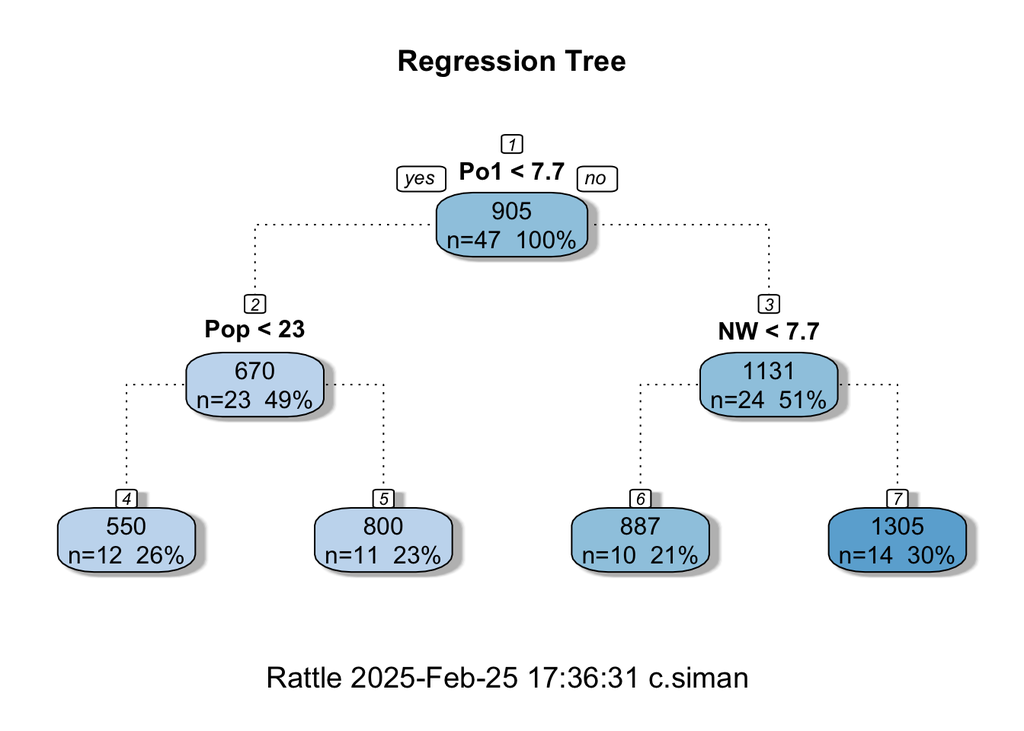

```r
par(bg = 'white')
fancyRpartPlot(rtree_model, main="Regression Tree", palettes=c("Blues"), type=1)
```

```r
rtree_model$variable.importance
```

```
##       Po1       Po2    Wealth      Ineq      Prob         M        NW       Pop
## 2497521.7 2497521.7 1628818.5 1602212.0 1520230.6 1388627.8 1245883.8  661770.6
##      Time        Ed        LF        So
##  601906.0  569545.9  203872.5  161800.8
```

### Random Forest

We train the random forest model using LOOCV to observe the cross-validated model performance

```r
# Specify the cross-validation method
ctrl <- trainControl(method="LOOCV")

# Fit a random forest model and use LOOCV to evaluate performance
rf_model_cv <- train(Crime~., data=df, method="rf", trControl=ctrl)
```

Here we see that the cross-validated RMSE is about `289`, much better than the regression tree model

```r
min(rf_model_cv$results$RMSE)
```

```
## [1] 289.4082
```

Train the random forest model using all variables and observe the model findings. Since this is a random forest model and is built using multiple trees, we cannot plot the final resulting tree.

```r
rf_model <- randomForest(Crime~., data=df)
summary(rf_model)
```

```
##                 Length Class  Mode
## call              3    -none- call
## type              1    -none- character
## predicted        47    -none- numeric
## mse             500    -none- numeric
## rsq             500    -none- numeric
## oob.times        47    -none- numeric
## importance       15    -none- numeric
## importanceSD      0    -none- NULL
## localImportance   0    -none- NULL
## proximity         0    -none- NULL
## ntree             1    -none- numeric
## mtry              1    -none- numeric
## forest           11    -none- list
## coefs             0    -none- NULL
## y                47    -none- numeric
## test              0    -none- NULL
## inbag             0    -none- NULL
## terms             3    terms  call
```

Similar to the regression tree, we see that the most important features are `Po1` and `Po2` by a very large margin

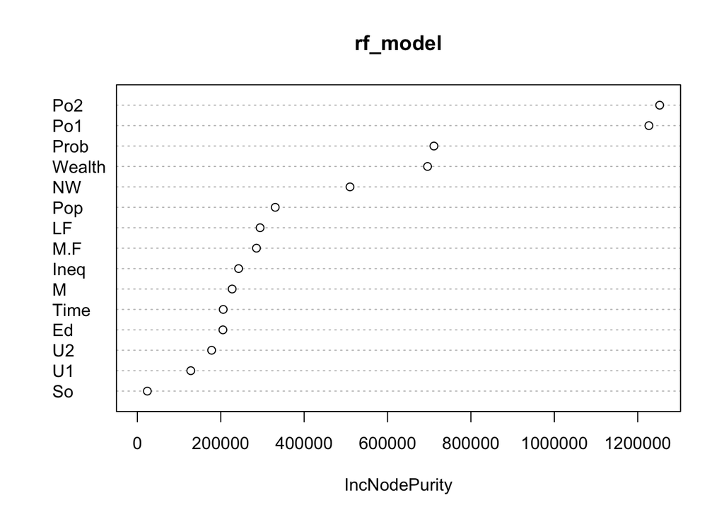

```r
varImpPlot(rf_model)
```

### Interpretation

- Much more explainable where we can plot out the resulting tree and understand how the model predicts where each observation will be categorised and determine its response variable
- However, based on the cross-validated RMSE, it is performing worse than random forest, which is in line with what we expect, where we sacrifice performance for better explainability

#### Random Forest

- From the cross-validated RMSE, the random forest model performs better than the regression tree, which is somewhat expected considering that the random forest is much less explainable than the regression tree model
- But we are still able to observe the feature importance to better understand how importance each variable is in training the random forest model

## Question 10.2

Describe a situation or problem from your job, everyday life, current events, etc., for which a logistic regression model would be appropriate. List some (up to 5) predictors that you might use.

**A:** In my job, we have customers making purchases with us on the app and one problem that we can tackle is to identify which customers are likely to be at risk of churn. A logistic regression model will be appropriate to solve this problem as we will be able to identify the level of risk that a customer is likely to churn, as well as using a threshold to determine whether a customer is likely to churn.

Some predictors we can use are:

- Average order frequency
- Average order value
- Days since last order
- Whether the customer is a new customer
- City of the customer

## Question 10.3.1

Using the GermanCredit data set germancredit.txt from http://archive.ics.uci.edu/ml/machine-learning-databases/statlog/german / (description at http://archive.ics.uci.edu/ml/datasets/Statlog+%28German+Credit+Data%29 ), use logistic regression to find a good predictive model for whether credit applicants are good credit risks or not. Show your model (factors used and their coefficients), the software output, and the quality of fit. You can use the glm function in R. To get a logistic regression (logit) model on data where the response is either zero or one, use family=binomial(link=”logit”) in your glm function call.

**A:**

**General approach:**

- Read data and rename columns for easy reference
- Split the dataframe into train and test sets
- Train the model on train set and observe the resulting model factors & coefficients
- Run the model on the test set and observe the model performance using AUC

Perform initialisation:

```r
# Load required libraries
library(tidyverse)
library(pROC)
```

Read the data into a dataframe and rename columns for easy reference

```r
df <- read.table("//Users/c.siman/Documents/Gatech/ISYE 6501 Intro to Analytics Modelling/Module 10 Advanced Regression/Homework 7/germancredit.txt", header = FALSE)

df <- df %>%
  rename(
    checking_acc_status = V1,
    duration_months = V2,
    credit_history = V3,
    purpose = V4,
    credit_amount = V5,
    savings_account_or_bonds = V6,
    employment_since = V7,
    installment_rate_of_income = V8,
    personal_status_and_sex = V9,
    other_debtors = V10,
    present_residence_since = V11,
    property = V12,
    age = V13,
    other_installment_plans = V14,
    housing = V15,
    number_existing_credits = V16,
    job = V17,
    number_people_liable_for_maintenance = V18,
    has_telephone = V19,
    is_foreign_worker = V20,
    is_bad_credit = V21
  )
```

Next, we transform the response column to a binary variable (0 or 1 instead of 1 or 2) for clarity

```r
df$is_bad_credit = df$is_bad_credit - 1
```

Observe the new dataframe

```r
describe(df)
```

```
## df
##
##  21  Variables      1000  Observations
## --------------------------------------------------------------------------------
## checking_acc_status
##        n  missing distinct
##     1000        0        4
##
## Value        A11   A12   A13   A14
## Frequency    274   269    63   394
## Proportion 0.274 0.269 0.063 0.394
## --------------------------------------------------------------------------------
## duration_months
##        n  missing distinct     Info     Mean  pMedian      Gmd      .05
##     1000        0       33    0.985     20.9     19.5    12.98        6
##      .10      .25      .50      .75      .90      .95
##        9       12       18       24       36       48
##
## lowest :  4  5  6  7  8, highest: 47 48 54 60 72
## --------------------------------------------------------------------------------
## credit_history
##        n  missing distinct
##     1000        0        5
##
## Value        A30   A31   A32   A33   A34
## Frequency     40    49   530    88   293
## Proportion 0.040 0.049 0.530 0.088 0.293
## --------------------------------------------------------------------------------
## purpose
##        n  missing distinct
##     1000        0       10
##
## Value        A40   A41  A410   A42   A43   A44   A45   A46   A48   A49
## Frequency    234   103    12   181   280    12    22    50     9    97
## Proportion 0.234 0.103 0.012 0.181 0.280 0.012 0.022 0.050 0.009 0.097
## --------------------------------------------------------------------------------
## credit_amount
##        n  missing distinct     Info     Mean  pMedian      Gmd      .05
##     1000        0      921        1     3271     2695     2773      709
##      .10      .25      .50      .75      .90      .95
```

[output cut: 120 more lines]

```
## Proportion 0.596 0.404
## --------------------------------------------------------------------------------
## is_foreign_worker
##        n  missing distinct
##     1000        0        2
##
## Value       A201  A202
## Frequency    963    37
## Proportion 0.963 0.037
## --------------------------------------------------------------------------------
## is_bad_credit
##        n  missing distinct     Info      Sum     Mean
##     1000        0        2     0.63      300      0.3
##
## --------------------------------------------------------------------------------
```

Now we split the dataframe into training and test sets with an 80-20 split

```r
df_len <- dim(df)[1]
test_sample <- sample(1:df_len, size=round(0.2*df_len), replace=FALSE)
train_set <- df[-test_sample,]
test_set <- df[test_sample,]
```

We now train the model using all variables on the training set. With this, we get the following coefficients for each factor:

```r
model <- glm(is_bad_credit~., data=train_set, family=binomial(link="logit"))
summary(model)
```

```
##
## Call:
## glm(formula = is_bad_credit ~ ., family = binomial(link = "logit"),
##     data = train_set)
##
## Coefficients:
##                                        Estimate Std. Error z value Pr(>|z|)
## (Intercept)                          -7.425e-01  1.224e+00  -0.607 0.543992
## checking_acc_statusA12               -5.053e-01  2.474e-01  -2.042 0.041121 *
## checking_acc_statusA13               -1.154e+00  4.355e-01  -2.650 0.008043 **
## checking_acc_statusA14               -1.575e+00  2.577e-01  -6.113 9.81e-10 ***
## duration_months                       2.568e-02  1.036e-02   2.480 0.013149 *
## credit_historyA31                     1.047e-01  6.090e-01   0.172 0.863518
## credit_historyA32                    -8.167e-01  4.557e-01  -1.792 0.073094 .
## credit_historyA33                    -1.011e+00  5.036e-01  -2.008 0.044685 *
## credit_historyA34                    -1.826e+00  4.730e-01  -3.861 0.000113 ***
## purposeA41                           -1.568e+00  4.261e-01  -3.680 0.000233 ***
## purposeA410                          -1.665e+00  9.781e-01  -1.702 0.088726 .
## purposeA42                           -4.892e-01  2.931e-01  -1.669 0.095051 .
## purposeA43                           -6.974e-01  2.817e-01  -2.476 0.013290 *
## purposeA44                           -6.274e-01  8.771e-01  -0.715 0.474446
## purposeA45                           -2.615e-01  5.970e-01  -0.438 0.661435
## purposeA46                            4.199e-01  4.487e-01   0.936 0.349371
## purposeA48                           -1.209e+00  1.219e+00  -0.992 0.321218
## purposeA49                           -5.806e-01  3.733e-01  -1.556 0.119826
## credit_amount                         1.550e-04  5.064e-05   3.060 0.002213 **
## savings_account_or_bondsA62          -1.585e-01  3.148e-01  -0.504 0.614569
## savings_account_or_bondsA63          -5.427e-01  4.773e-01  -1.137 0.255464
## savings_account_or_bondsA64          -1.608e+00  6.228e-01  -2.582 0.009829 **
## savings_account_or_bondsA65          -1.252e+00  3.229e-01  -3.879 0.000105 ***
## employment_sinceA72                   2.915e-01  4.623e-01   0.631 0.528366
## employment_sinceA73                   1.091e-01  4.419e-01   0.247 0.804897
## employment_sinceA74                  -5.681e-01  4.849e-01  -1.172 0.241327
## employment_sinceA75                  -1.928e-01  4.494e-01  -0.429 0.667853
## installment_rate_of_income            3.112e-01  9.847e-02   3.161 0.001575 **
## personal_status_and_sexA92            3.442e-01  4.765e-01   0.722 0.470049
## personal_status_and_sexA93           -2.247e-01  4.687e-01  -0.479 0.631666
## personal_status_and_sexA94            1.496e-01  5.419e-01   0.276 0.782585
## other_debtorsA102                     3.378e-01  4.841e-01   0.698 0.485285
## other_debtorsA103                    -1.134e+00  5.348e-01  -2.120 0.033983 *
```

[output cut: 11 more lines]

```
## jobA173                               3.135e-01  7.206e-01   0.435 0.663557
## jobA174                               3.941e-01  7.444e-01   0.529 0.596482
## number_people_liable_for_maintenance  2.246e-01  2.778e-01   0.809 0.418669
## has_telephoneA192                    -3.221e-01  2.263e-01  -1.424 0.154589
## is_foreign_workerA202                -1.095e+00  6.465e-01  -1.694 0.090238 .
## ---
## Signif. codes:  0 '***' 0.001 '**' 0.01 '*' 0.05 '.' 0.1 ' ' 1
##
## (Dispersion parameter for binomial family taken to be 1)
##
##     Null deviance: 977.38  on 799  degrees of freedom
## Residual deviance: 713.44  on 751  degrees of freedom
## AIC: 811.44
##
## Number of Fisher Scoring iterations: 5
```

Now we observe the predictions of the model on the test set. Looking at the model performance using area under curve (AUC), we see that this model’s AUC is about `79%`

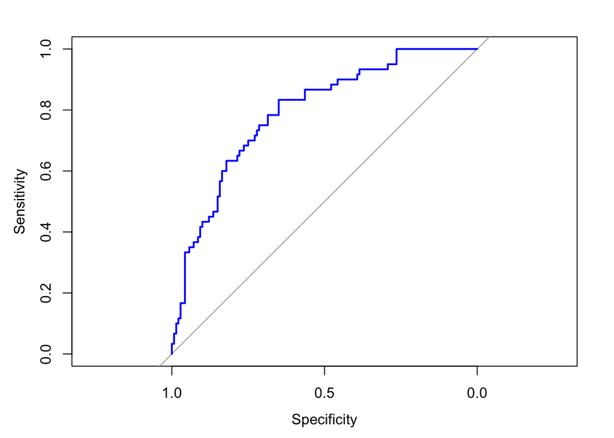

```r
# Get model predictions on test set
pred <- predict(model, test_set, type="response")

# Plot ROC & calculate AUC
roc = roc(test_set$is_bad_credit, pred)
plot(roc, col="blue")
```

```r
auc(test_set$is_bad_credit, pred)
```

```
## Area under the curve: 0.7925
```

## Question 10.3.2

Because the model gives a result between 0 and 1, it requires setting a threshold probability to separate between “good” and “bad” answers. In this data set, they estimate that incorrectly identifying a bad customer as good, is 5 times worse than incorrectly classifying a good customer as bad. Determine a good threshold probability based on your model.

**A:**

**General approach:**

- Loop over a series of possible thresholds to use and track the `Positive Prediction Rate` & `Overall Accuracy`
- The aim is to maximise both metrics such that we get a high `Positive Prediction Rate` (to minimise False Positives - i.e. incorrectly identifying bad customers as good) while retaining a high overall accuracy of the model
- Therefore, we choose a threshold that gets high values for both metrics

Loop over a series of thresholds and track the prediction performance

```r
# Create empty lists
threshold_list <- list()
pos_pred_list <- list()
accuracy_list <- list()

# Loop over thresholds and record the prediction performance
for (threshold in seq(0.2, 0.8, by=0.05)) {
  binary_pred <- cbind(ifelse(pred>threshold, 1, 0))
  confusion_matrix <- confusionMatrix(data=as.factor(binary_pred), reference=as.factor(test_set$is_bad_credit))
  threshold_list <- rbind(threshold_list, threshold)
  pos_pred_list <- rbind(pos_pred_list, confusion_matrix[["byClass"]][["Pos Pred Value"]])
  accuracy_list <- rbind(accuracy_list, confusion_matrix[["overall"]][["Accuracy"]])
}
```

Plot the accuracy-threshold graph and the positive-prediction-value-threshold graph to find the best possible threshold to use to maximise both metrics.

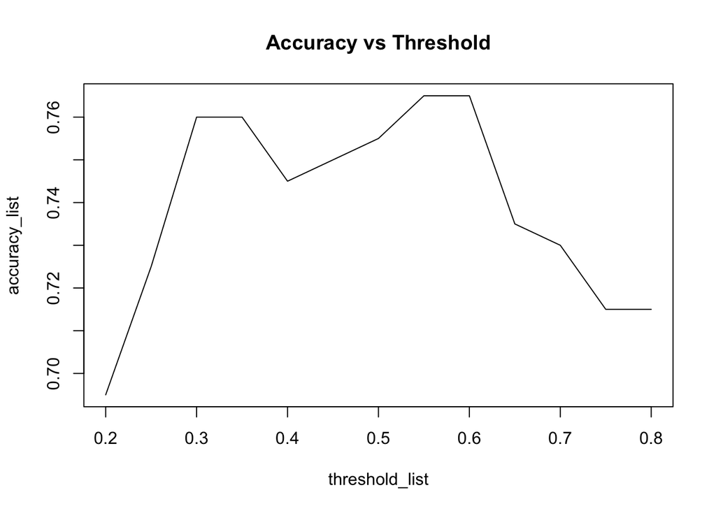

```r
plot(threshold_list, accuracy_list, main="Accuracy vs Threshold", type="l")
```

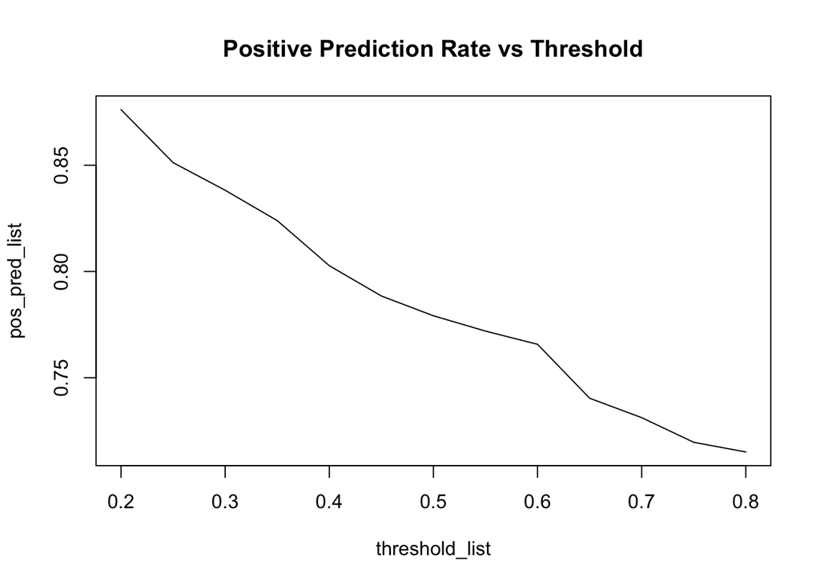

```r
plot(threshold_list, pos_pred_list, main="Positive Prediction Rate vs Threshold", type="l")
```

Using the chosen threshold, generate the confusion matrix to observe the model prediction summary

```r
binary_pred <- cbind(ifelse(pred>0.35, 1, 0))
confusionMatrix(data=as.factor(binary_pred), reference=as.factor(test_set$is_bad_credit))
```

```
## Confusion Matrix and Statistics
##
##           Reference
## Prediction   0   1
##          0 117  25
##          1  23  35
##
##                Accuracy : 0.76
##                  95% CI : (0.6947, 0.8174)
##     No Information Rate : 0.7
##     P-Value [Acc > NIR] : 0.03595
##
##                   Kappa : 0.4231
##
##  Mcnemar's Test P-Value : 0.88523
##
##             Sensitivity : 0.8357
##             Specificity : 0.5833
##          Pos Pred Value : 0.8239
##          Neg Pred Value : 0.6034
##              Prevalence : 0.7000
##          Detection Rate : 0.5850
##    Detection Prevalence : 0.7100
##       Balanced Accuracy : 0.7095
##
##        'Positive' Class : 0
##
```